# Hummus

[output not shown]

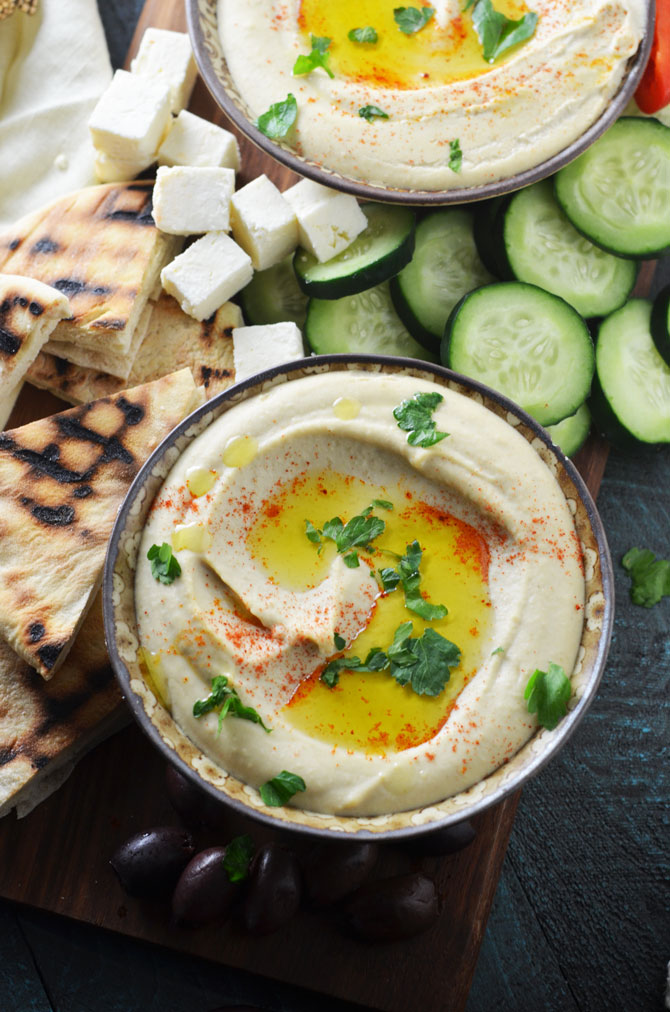

## Ingredients

FOR THE HUMMUS TEHINA:

1 cup dried chickpeas

2 teaspoons baking soda

1 1/2 cups Basic Tehina Sauce (recipe below)

1 teaspoon kosher salt

1/4 teaspoon ground cumin

Paprika

Chopped or torn fresh parsley leaves

Olive oil, for drizzling

FOR THE BASIC TEHINA SAUCE:

1 head garlic

3/4 cup lemon juice (from 3 lemons)

1 1/2 teaspoons kosher salt

2 generous cups tehina

1/2 teaspoon ground cumin

## Directions

Place the chickpeas in a large bowl with 1 teaspoon of the baking soda and cover with water. (The chickpeas will double in volume, so use more water than you think you need.) Soak the chickpeas overnight at room temperature. The next day, drain the chickpeas and rinse under cold water.

Place the chickpeas in a large pot with the remaining 1 teaspoon baking soda and add cold water to cover by at least 4 inches. Bring the chickpeas to a boil over high heat, skimming off any scum that rises to the surface. Lower the heat to medium, cover the pot, and continue to simmer for about 1 hour, until the chickpeas are completely tender. Then simmer them a little more. (The secret to creamy hummus is overcooked chickpeas: don’t worry if they are mushy and falling apart a little.) Drain.

As the chickpeas cook, make the Basic Tehina Sauce. Break up the head of garlic with your hands, letting the unpeeled cloves fall into a blender. Add the lemon juice and 1/2 teaspoon of the salt. Blend on high for a few seconds until you have a coarse puree. Let the mixture stand for 10 minutes to let the garlic mellow.

Pour the mixture through a fine-mesh strainer set over a large mixing bowl, pressing on the solids to extract as much liquid as possible. Discard the solids. Add the tenia to the strained lemon juice in the bowl, along with the cumin and 1 teaspoon of the salt.

Whisk the mixture together until smooth (or use a food processor), adding ice water, a few tablespoons at a time, to thin it out. The sauce will lighten in color as you whisk. When the tehina seizes up or tightens, keep adding ice water, bit by bit (about 1 1/2 cups in total), whisking energetically until you have a perfectly smooth, creamy, thick sauce.

Taste and add up to 1 1/2 teaspoons more salt and cumin if you like. If you’re not using the sauce immediately, whisk in a few tablespoons of ice water to loosen it before refrigerating. The tehina sauce will keep a week refrigerated, or it can be frozen for up to a month.

Combine the chickpeas, 1 1/2 cups Basic Tehina Sauce, remaining salt and cumin in a food processor. Puree the hummus for several minutes, until it is smooth and uber-creamy. Then puree it some more!

To serve, spread the hummus in a shallow bowl, dust with paprika, top with parsley and more tehina sauce if you like, and drizzle generously with oil.